[figure not shown]

[OHI Science](http://ohi-science.org) | [Citation policy](http://ohi-science.org/citation-policy/)

# Ocean Acidification Pressure

OHI+ Palmyra 2020 Assessment

Compiled on Thu Aug 20 10:04:36 2020 by orofino

# Summary

This ocean acidification (OA) pressure layer for Palmyra Atoll is derived from a monthly raster of aragonite saturation states. The global assessment processes this data to rescale values 0-1 based on a biological threshold and the proportional change compared to a historical mean. This script starts with the rescaled raster and does the following:

- Clips rescaled rasters to the coast using a 3 nautical mile offshore buffer
- Resamples raster to ~ 1km<sup>2</sup> and reprojects to US Albers projection

# Data

**Reference**: [Feely et al.(2009)](https://darchive.mblwhoilibrary.org/bitstream/handle/1912/3180/22-4_feely.pdf?sequence=1&isAllowed=y)

**Downloaded**: July 19, 2017

**Description**: Aragonite Saturation State $\Omega_{arg}$

**Native data resolution**: 1 degree cells

**Time range**: 1880-1889 and 1958-2100, monthly data provided for each year. Future years are based on model projections for RCP 8.5. Previous years are hindcast/historical data.

**Format**: NetCDF

**Citation information**: Woods Hole Oceanographic Institution. 2014 update to data originally published in: Feely, R.A., S.C. Doney, and S.R. Cooley. 2009. Ocean acidification: Present conditions and future changes in a high-CO2 world. Oceanography 22(4):36–47

**Notes about the data**: This data was shared with NCEAS by Ivan Lima from Woods Hole Institute for Oceanography in July 2017. Originally, data were provided from 1958 - 2016; additional years of data up until 2020 were received from Ivan Lima. The data came as NetCDFs with a resolution of about 1 degree. The data values are monthly average surface Ω aragonite saturation state.

# Setup

```r
library(tidyverse)
library(raster)
library(ncdf4)
library(maps)
library(parallel)
library(foreach)
library(doParallel)
library(RColorBrewer)
library(fasterize)
library(rasterVis)
library(here)
library(gstat)
library(scales)
library(animation)

# Source and set file paths
source(here('src/R/common.R'))

raw_dir <- file.path(dir_M, 'git-annex/globalprep/_raw_data')
dir_prs <- '~/github/pal-prep/prep/pressures/oa/v2020'
```

# Methods

## Load Processed Data

Data for ocean acidification has been processed for the global assessment to give a value 0-1 for each year from 1958 - 2020 using both a historical reference period and a biological reference point. All cells with values less than 1, indicating an undersaturated state, are set equal to the highest stressor level, 1. For all other cells, rescaling the aragonite saturation state value to between 0 and 1 relies upon the change in saturation relative to the reference period. Additional information on how this data is processed to obtain 0-1 scores can be found [here](https://raw.githack.com/OHI-Science/ohiprep_v2020/gh-pages/globalprep/prs_oa/v2017/create_oa_layer.html).

```r
oa_rasts <- c(list.files(file.path(dir_M, "git-annex/globalprep/prs_oa/v2017/output"),
                         full.names=T))

# Plot the 2020 data to check rasters:
plot(raster(oa_rasts[64]), col=cols,box=F,axes=F,
     main = 'Rescaled Ωaragonite layer for 2020')
```

## Reproject Global Data

Reproject the global data to US Albers and crop to Palmyra’s extent

```r
# Only need oa rasters 2-64, these are the annual oa rasters
oa_rast_annual <- oa_rasts[2:64]

# 3nm Buffer raster for cropping
three_nm <- ocean_rast3_100
three_nm <- raster::crop(three_nm, usalb_ext3) # Crop to Palmyra extent
plot(three_nm)

# Register 10 cores for parallel processing
registerDoParallel(10)

foreach(file = oa_rast_annual) %dopar% {
  #file = oa_rast_annual[1]

  yr = substr(file,72,75)

  r <- raster(file)

  rast_reproj <- projectRaster(from=r, to=three_nm, crs=us_alb,
                               method="ngb", over=FALSE) %>%
    raster::resample(three_nm, method="ngb",
                     filename = sprintf("%s/dataprep/prs_oa/output/oa_rasts_us_albers/oa_%s.tif",
                                        dir_anx, yr), overwrite = TRUE) %>%
    mask(three_nm, filename = sprintf("%s/dataprep/prs_oa/output/oa_rasts_us_albers_coastal/oa_coastal_%s.tif",
                                      dir_anx, yr), overwrite = TRUE) %>%
    raster::crop(usalb_ext3) %>%
    writeRaster(., filename = paste0(file.path(dir_anx), '/dataprep/prs_oa/output/oa_rasts_us_albers_coastal/oa_',
                                     yr, '.tif'), overwrite=T)

}

# Plot 2020 raster to check:
plot(raster(file.path(dir_anx,
                      "dataprep/prs_oa/output/oa_rasts_us_albers_coastal/oa_coastal_2020.tif")))

plot(raster(file.path(dir_anx,
                      "dataprep/prs_oa/output/oa_rasts_us_albers/oa_2020.tif")))

plot(raster(file.path(dir_anx,
                      "dataprep/prs_oa/output/oa_rasts_us_albers_coastal/oa_2020.tif")))
```

## Check for Gapfilled Cells

Some of the cells in the cropped rasters look like they’re missing. Check global raster for interpolated cells.

```r
# Interpolated global data: CRS = mollewide equal area
interp_gl <- raster(file.path(dir_M,
                              'git-annex/globalprep/prs_oa/v2017/output/oa_interpolated_cells.tif'))

# Get extent in mollewide equal area for Palmyra
extent(pal_buffer_3nm)
moll_ext <- extent(-16200173, -16182605, 719838.4, 733708.5)

# Crop global raster to Palmyra ext
pal_interp <- interp_gl %>%
  crop(moll_ext)

# Plot
plot(pal_interp, col=cols, box=F, axes=F, main='Interpolated cells')
# Blank - maybe this means no cells were interpolated?

## Check shapefile over the raster
plot(raster(file.path(dir_anx, "dataprep/prs_oa/output/oa_rasts_us_albers/oa_2020.tif")))
plot(pal_shore_alb, add = T, col = "grey")
```

Must just be lower resolution than the shapefiles, looks like its supposed to be the land area of Palmyra, it just doesn’t have the same level of detail.

## Extract Values

Extract values for Palmyra

```r
## Read in raster files
pressure_stack <- lapply(list.files(file.path(dir_anx, 'dataprep/prs_oa/output/oa_rasts_us_albers'),
                                    full.names=T), raster) %>%
  brick()

# Extract data for Palmyra:
pal_regionstats <- cellStats(pressure_stack, mean)%>%
  as.data.frame() %>%
  rename(pressure_score = ".") %>%
  tibble::rownames_to_column("file_name") %>%
  mutate(year = substr(file_name, 4, 7)) %>%
  select(-file_name) %>%
  mutate(region_id = 1,
         year = as.numeric(year))

# Finalized data frame for pressure score:
oa_data <- pal_regionstats %>%
  filter(year >= 2005) %>%
  dplyr::select(region_id, year, pressure_score)

# Save to output folder
write_csv(oa_data, file.path(dir_prs, "output/oa_pressure.csv"))
```

## Save to Toolbox

```r
oa_data <- read_csv(file.path(dir_prs, "output/oa_pressure.csv"))
write_csv(oa_data, file.path(dir_scores, "layers/prs_cc_oa.csv"))
```

# Results

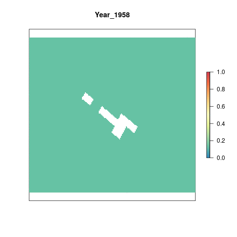

```r
oa_coastal_rasts <- list.files(file.path(dir_anx, 'dataprep/prs_oa/output/oa_rasts_us_albers'),
                               full.names = T) %>%
                           stack()

names(oa_coastal_rasts) <- paste0("Year_", substr(names(oa_coastal_rasts),4,7))

# Make a gif animation
animation::saveGIF({
  for(i in 1:nlayers(oa_coastal_rasts)){
     plot(oa_coastal_rasts[[i]], col='cornsilk2',
          main=names(oa_coastal_rasts[[i]]), axes=F, legend=F)
      # don't forget to fix the zlimits
    plot(oa_coastal_rasts[[i]], zlim=c(0,1), axes=F, col=cols, add=T)

  }
}, movie.name = 'oa_annual_rescaled.gif')
```

## 2020 scores

Check the scores for 2020.

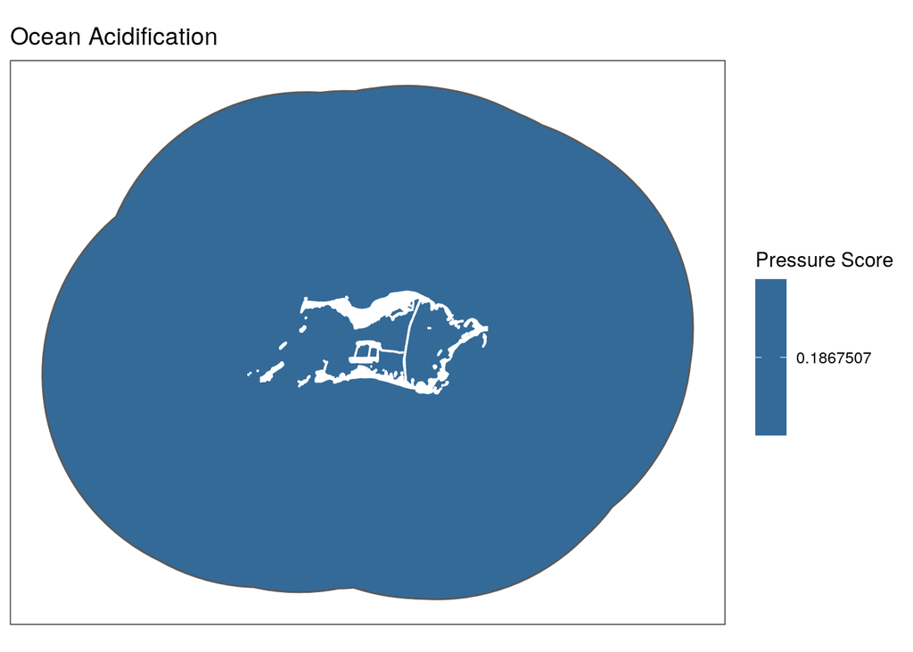

```r
# Source the plot scores function
source(here('src/R/plot_scores.R'))

# Use oa output data
oa_data <- read_csv(file.path(dir_prs, "output/oa_pressure.csv"))

last_year <- oa_data %>%
  filter(year==2020)

## map_scores is a function to plot a tmap map of the scores
map_scores(score_obj = last_year,
           score_var = last_year$pressure_score,
           scale_label = "Pressure Score",
           map_title = "Ocean Acidification")
```

## Visualize Through Time

Basic visualization of pressure scores over time.

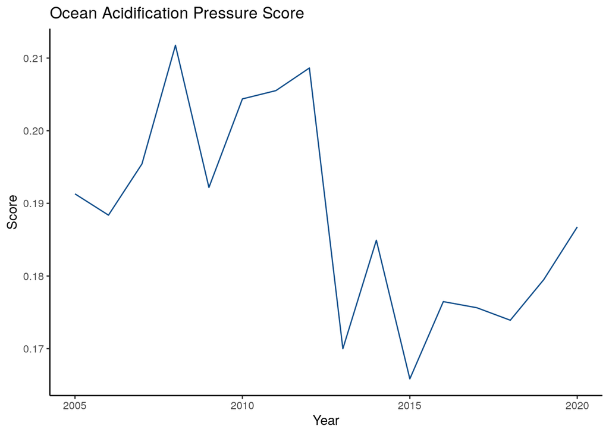

```r
# Graph pressure scores over time
oa_overtime <-ggplot(oa_data)+
  geom_line(aes(x=year, y = pressure_score), color="dodgerblue4")+
  ggtitle("Ocean Acidification Pressure Score") +
  ylab("Score") +
  xlab("Year") +
  theme_classic()

# Save output
#ggsave(file.path(dir_prs, "figs/scores_2005-2020.png"), width=7, height=5, dpi=300)

oa_overtime
```